# Practical Machine Learning Course Project

dicenslice

June 5, 2016

# Practical Machine Learning Assignment

## Introduction

Using devices such as Jawbone Up, Nike FuelBand, and Fitbit it is now possible to collect a large amount of data about personal activity relatively inexpensively. These type of devices are part of the quantified self movement – a group of enthusiasts who take measurements about themselves regularly to improve their health, to find patterns in their behavior, or because they are tech geeks. One thing that people regularly do is quantify how much of a particular activity they do, but they rarely quantify how well they do it. In this project, your goal will be to use data from accelerometers on the belt, forearm, arm, and dumbell of 6 participants. They were asked to perform barbell lifts correctly and incorrectly in 5 different ways.

## Exploratory Data Analysis:

The utilized libraries are loaded and the data is read in:

```r
library(randomForest);library(caret);library(reshape2);library(corrplot)
library(seriation)
training <- read.csv("data/pml-training.csv"
                     ,na.strings = c("#DIV/0!",NA,".")
                     ,stringsAsFactors = F)
testing <- read.csv("data/pml-testing.csv")
```

A number of variables have a high percentage of missing cases. These are omitted:

```r
omit <- (apply(training,2,function(x) sum(is.na(x))/length(x))>.9)
training2 <- training[,omit==FALSE]
```

Boxplot of the remaining ~60 variables:

```r
training2.melt <- melt(training2[,-c(1:6,60)])
```

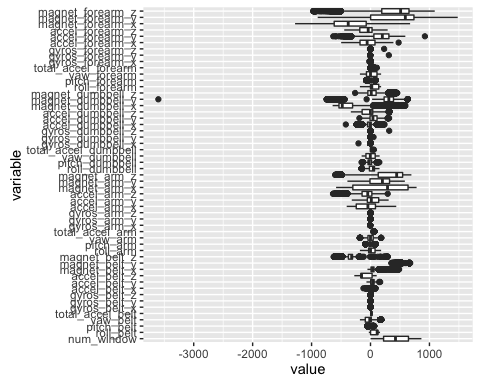

```r
box.plot <- ggplot(data = training2.melt,aes(x=variable,y=value))+
  geom_boxplot() + coord_flip()
box.plot
```

Correlation amongst the variables:

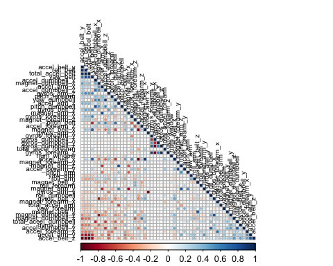

```r
cor.mat <- round(cor(training2[,-c(1:6,60)]),2)
corrplot(cor.mat,method = "circle",type = "lower",tl.cex = .6,order = "FPC"
         ,tl.col = "black")
```

## Modeling & Results

The training dataset is divided into two parts for training and testing purposes:

```r
trn <- createDataPartition(y=training2$classe,p = .7, list=F)
trainset <- training2[trn,]
testset <- training2[-trn,]
```

```r
trainset2 <- (trainset[,-c(1:6)])
rf.imp <- randomForest(as.factor(classe)~.,data = trainset2,
                       importance = TRUE,ntree = 100)
imp <- data.frame("var"=row.names(rf.imp$importance),
                  "vls"=rf.imp$importance[,"MeanDecreaseGini"],
                  row.names = NULL)
imp <- imp[order(imp$vls,decreasing = T),]
imp[1:10,]
```

```
##                  var       vls
## 1         num_window 1057.2168
## 2          roll_belt  826.7825
## 4           yaw_belt  533.1222
## 42     pitch_forearm  523.2182
## 40 magnet_dumbbell_z  499.3570
## 39 magnet_dumbbell_y  459.6392
## 3         pitch_belt  455.9721
## 41      roll_forearm  377.0114
## 38 magnet_dumbbell_x  298.5416
## 28     roll_dumbbell  278.8374
```

```r
varn <- as.character(imp[1:10,1])
```

A random forest model is run for the training set:

```r
set.seed(42)
rf <- train(as.factor(classe)~.,data=trainset[,c(varn,"classe")],
            method = "rf",
            trControl =trainControl(method = "cv",
                                      number=3,repeats=1,
                                      verboseIter = F))
```

The results are given below. The accuracy of the model is pretty high:

```r
rf.predict <- predict(rf,newdata = testset[,varn])
rf.conmat <- confusionMatrix(rf.predict,testset$classe)
rf.conmat$table
```

```
##           Reference
## Prediction    A    B    C    D    E
##          A 1674    3    0    0    0
##          B    0 1135    2    0    0
##          C    0    1 1023    2    0
##          D    0    0    1  962    1
##          E    0    0    0    0 1081
```